# Final Project EDA Report

### About Pollutants - by hour

Under “Quick facts about aqi” above, I showed that this dataset is collected over 4 different times. I organized information about pollutants, by time.

```r
#pollutants by time
aqi %>%
  group_by(hour) %>%
  summarise(
    avg_pm25 = mean(pm25, na.rm = TRUE),
    avg_pm10 = mean(pm10, na.rm = TRUE),
    avg_o3 = mean(o3, na.rm = TRUE),
    avg_no2 = mean(no2, na.rm = TRUE),  #using RAW concentrations
    avg_so2 = mean(so2, na.rm = TRUE),
    avg_co = mean(co, na.rm = TRUE)
    )
```

```
## # A tibble: 4 x 7
##    hour avg_pm25 avg_pm10 avg_o3 avg_no2 avg_so2 avg_co
##   <dbl>    <dbl>    <dbl>  <dbl>   <dbl>   <dbl>  <dbl>
## 1    9.     138.     74.8   29.7    18.5    16.9  12.1
## 2   10.     142.     83.4   28.2    19.2    12.5   9.56
## 3   11.     126.     71.3   34.8    14.8    15.0  13.3
## 4   12.     115.     73.3   43.5    13.7    10.5  11.3
```

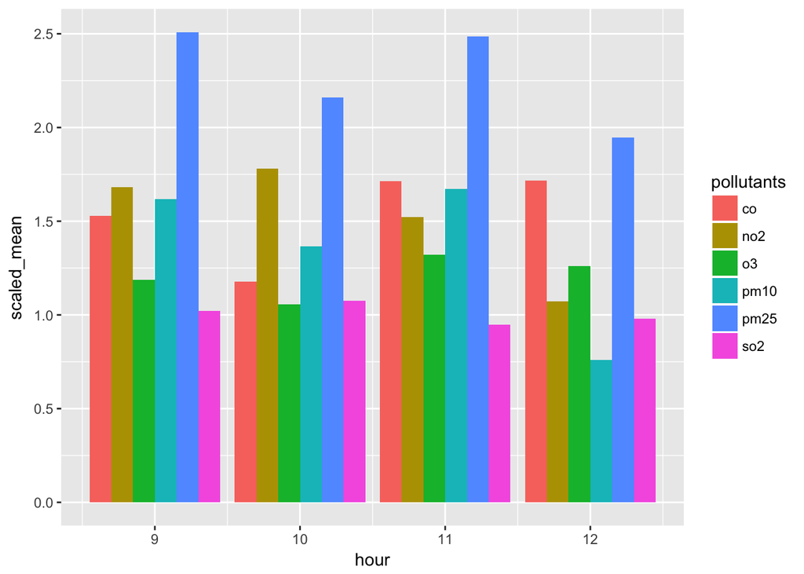

```r
#but since the pollutants are measured in different units, it would be much sensible to compare their mean concentrations after scaling them like the following:
aqi %>%
  group_by(hour) %>%
  summarise(pm25    = mean(pm25, na.rm = TRUE)/sd(pm25, na.rm = TRUE), #scaled mean
            pm10    = mean(pm10, na.rm = TRUE)/sd(pm10, na.rm = TRUE),
            o3      = mean(o3,   na.rm = TRUE)/sd(o3,   na.rm = TRUE),
            no2     = mean(no2,  na.rm = TRUE)/sd(no2,  na.rm = TRUE),
            so2     = mean(so2,  na.rm = TRUE)/sd(so2,  na.rm = TRUE),
            co      = mean(co,   na.rm = TRUE)/sd(co,   na.rm = TRUE)) %>%
  gather(pm25, pm10, o3, no2, so2, co, key = pollutants, value = scaled_mean) %>%
  ggplot( aes( x = hour ))+
  geom_bar( aes(y = scaled_mean, fill = pollutants), stat = "identity", position = "dodge")
```

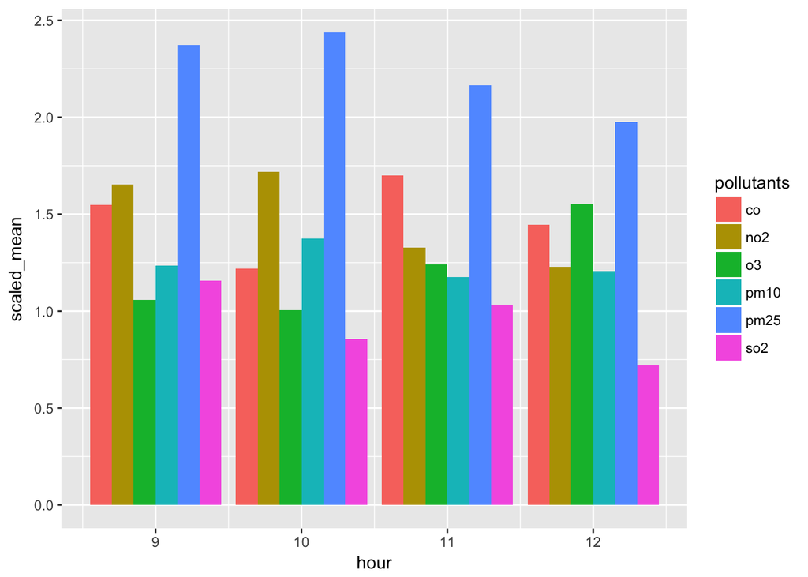

```r
#As you can see, after scaling, pm25 has the greatest concentration at 4 different times.

#Or another way (very similar to above above)
aqi %>%
  mutate(
    sc_pm25 = pm25 / sd(pm25, na.rm = T),
    sc_pm10 = pm10 / sd(pm10, na.rm = T),
    sc_o3   = o3   / sd(o3,   na.rm = T),
    sc_no2  = no2  / sd(no2,  na.rm = T),
    sc_so2  = so2  / sd(so2,  na.rm = T),
    sc_co   = co   / sd(co,   na.rm = T)
  ) %>%
  group_by(hour) %>%
  summarise( pm25    = mean(sc_pm25, na.rm = TRUE),
             pm10    = mean(sc_pm10, na.rm = TRUE),
             o3      = mean(sc_o3,   na.rm = TRUE),
             no2     = mean(sc_no2,  na.rm = TRUE),
             so2     = mean(sc_so2,  na.rm = TRUE),
             co      = mean(sc_co,   na.rm = TRUE)
             )%>%
  gather(pm25, pm10, o3, no2, so2, co, key = pollutants, value = scaled_mean) %>%
  ggplot( aes( x = hour ))+
  geom_bar( aes(y = scaled_mean, fill = pollutants), stat = "identity", position = "dodge")
```

Judging from both bar plots above, one may think pm25 is the most problematic pollutant. However, AQI scores (later) will tell us that it is actually another pollutant that is responsible for raising AQI score. The higher the AQI, the worse.

Also, the units given in the data is not the same as units used for calculating the AQI score by the EPA. Therefore, the above plots are misleading.

### About Pollutants - by pollutants!

Statistics for each of the 6 pollutants can be found below.

```r
# grouping by pollutants
poll_stat <- aqi %>%
  select(pm25, pm10, o3, no2, so2, co) %>%
  gather() %>%
  group_by(key) %>%
  summarise(min   = min(value, na.rm = TRUE),
            max   = max(value, na.rm = TRUE),
            rng   = max - min,
            mean  = mean(value, na.rm = TRUE),    #center
            median = median(value, na.rm = TRUE),
            sd    = sd(value, na.rm = TRUE),      #spread
            iqr   = IQR(value, na.rm = TRUE))
poll_stat
```

```
## # A tibble: 6 x 8
##   key     min   max   rng  mean median    sd   iqr
##   <chr> <dbl> <dbl> <dbl> <dbl>  <dbl> <dbl> <dbl>
## 1 co       0.   67.   67.  11.7    10.  7.84    8.
## 2 no2      0.  103.  103.  16.9    15. 11.2    13.
## 3 o3       1.  290.  289.  33.0    28. 28.0    23.
## 4 pm10     0.  999.  999.  75.7    63. 60.7    48.
## 5 pm25     1.  544.  543. 132.    139. 58.2    77.
## 6 so2      0.  119.  119.  14.2     9. 14.6    13.
```

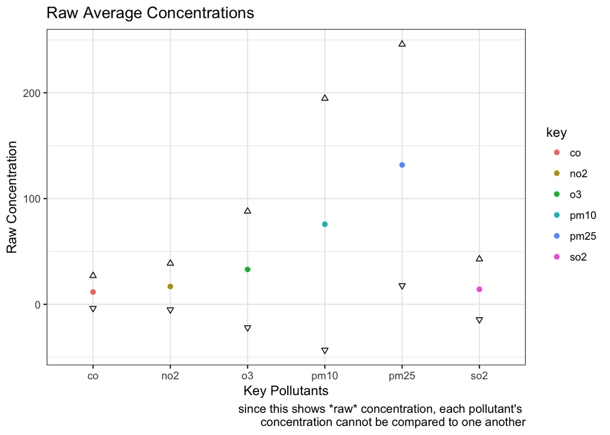

```r
#Raw Concentration
poll_stat %>%
  mutate(sdup = mean + 1.96*sd,      #95% CI
         sddw = mean - 1.96*sd) %>%
  ggplot(aes(key)) +
  geom_point(aes(y = mean, color = key)) +
  geom_point(aes(y = sdup), pch = 2) +    #one 1.96sd up from mean
  geom_point(aes(y = sddw), pch = 6) +    #one 1.96sd down from mean
  labs(title = "Raw Average Concentrations",
       x = "Key Pollutants",
       y = "Raw Concentration",
       caption = paste("since this shows *raw* concentration, each pollutant's
                       concentration cannot be compared to one another")) +
  theme_bw()
```

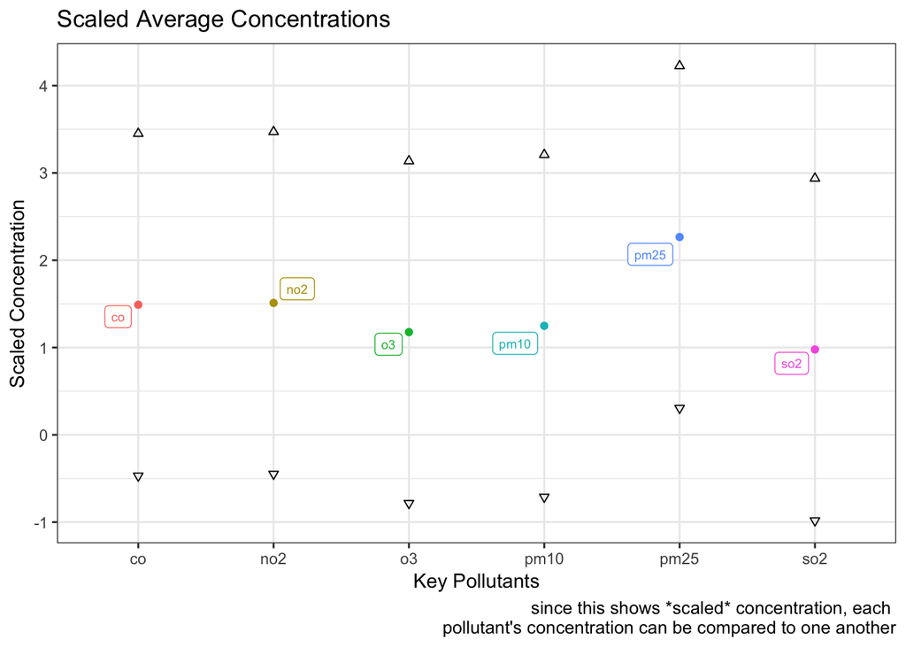

```r
#Scaled Concentration
poll_stat_helper <- poll_stat %>%
  mutate(scaled = mean / sd) %>%
  select(key, scaled)


poll_stat %>%
  mutate(scaled = mean / sd,
         sdup = scaled + 1.96,     #95% CI
         sddw = scaled - 1.96) %>%
  ggplot(aes(key)) +
  geom_point(aes(y = scaled, color = key)) +
  geom_point(aes(y = sdup), pch = 2) +    # upper bound for 95% CI
  geom_point(aes(y = sddw), pch = 6) +    # lower bound for 95% CI
  labs(title = "Scaled Average Concentrations",
       x = "Key Pollutants",
       y = "Scaled Concentration",
       caption = paste("since this shows *scaled* concentration, each
                       pollutant's concentration can be compared to one another")) +
  geom_label_repel(aes(label = key, y = scaled, color = key),
                   data = poll_stat_helper,
                   segment.color = NA,
                   size = 2.5) +
  theme_bw() +
  theme(legend.position = "none")
```

Again from the plots above, pm25 ‘seems’ like the most problematic pollutant. As aforementioned, the units given in the data is not the same as units used for calculating the AQI score. Therefore, the above plots are misleading.

### Quick check on Multicorrelinearity

I am showing correlation matrix, and the maximum correlation.

```
##            pm25       pm10           o3         no2         so2
## pm25  1.0000000 0.72945169 -0.014986703 0.467781643  0.29043691
## pm10  0.7294517 1.00000000  0.014318155 0.372150270  0.23828940
## o3   -0.0149867 0.01431816  1.000000000 0.009317727 -0.01205936
## no2   0.4677816 0.37215027  0.009317727 1.000000000  0.42061910
## so2   0.2904369 0.23828940 -0.012059357 0.420619096  1.00000000
## co    0.3677345 0.32130742 -0.076319868 0.260847912  0.33847248
##               co
## pm25  0.36773454
## pm10  0.32130742
## o3   -0.07631987
## no2   0.26084791
## so2   0.33847248
## co    1.00000000
```

```
## [1] 0.7294517 0.7294517
```

The maximum correlation is 0.7294517. The rest are not very concerning. Overall, multicollinearity does **not** seem to be a major problem.

### Let’s calculate AQI scores.

First, some unit conversions are conducted to use EPA’s formula. Then several numerical vectors that contain appropriate breakpoints are created for each pollutants. Depending on the two breakpoints that each concentration falls in, each concentration is assigned fitting categories: “very good”, “good”, “moderate”, “bad”, “very bad”, “dangerous”, “toxic”. Of course, these categories indicate the quality of the air. Some lengthy functions are created to convert the concentrations to AQI scores.

```
## [1] 0.01 2.90
```

```
## [1]    0 1190
```

```
## [1]    0 1030
```

```
## [1]  0 67
```

```
## [1]   1 544
```

```
## [1]   0 999
```

```
## # A tibble: 1,590 x 4
##    pm25      pm25_cat pm10      pm10_cat
##    <dbl+lbl> <fct>    <dbl+lbl> <fct>
##  1  80       bad      30        very good
##  2 113       bad      40        very good
##  3  72       bad      44        very good
##  4  80       bad      32        very good
##  5  87       bad      48        very good
##  6  87       bad      37        very good
##  7  79       bad      53        very good
##  8 180       very bad 90        good
##  9  76       bad      33        very good
## 10  98       bad      40        very good
## # ... with 1,580 more rows
```

```
## # A tibble: 1,590 x 28
##    locationid stationname latitude longitude pm25  pm25_cat aqi_pm25 pm10
##         <int> <chr>          <dbl>     <dbl> <dbl> <fct>       <dbl> <dbl>
##  1          1 Dongcheng …     39.9      116.  80   bad          164. 30
##  2          2 Temple of …     39.9      116. 113   bad          181. 40
##  3          3 West Park …     39.9      116.  72   bad          160. 44
##  4          4 West Wansh…     39.9      116.  80   bad          164. 32
##  5          5 Chaoyang O…     40.0      116.  87   bad          167. 48
##  6          6 Chaoyang A…     39.9      116.  87   bad          167. 37
##  7          7 Haidian Wa…     40.0      116.  79   bad          163. 53
##  8          8 The Haidia…     40.1      116. 180   very bad     230. 90
##  9          9 Haidian Be…     40.0      116.  76   bad          162. 33
## 10         10 Fengtai ga…     39.9      116.  98   bad          173. 40
## # ... with 1,580 more rows, and 20 more variables: pm10_cat <fct>,
## #   aqi_pm10 <dbl>, o3 <dbl+lbl>, o3_cat <fct>, aqi_o3 <dbl>,
## #   no2 <dbl+lbl>, no2_cat <fct>, aqi_no2 <dbl>, so2 <dbl+lbl>,
## #   so2_cat <fct>, aqi_so2 <dbl>, co <dbl+lbl>, co_cat <fct>,
## #   aqi_co <dbl>, pressure <int>, wind <dbl>, hour <dbl>, temp <dbl>,
## #   dew <dbl>, humid <dbl>
```

### ‘The’ AQI score

Currently, we have AQI scores for each of the 6 pollutants. Then for each row, which AQI score are we supposed to use? The answer is the the maximum AQI score. That is, for each row we identify the maximum AQI score, and that score is ‘the’ final AQI score for that area at that particular time.

```r
# Creating a column with highest AQI score for each row

#data object only containing the pollutants' AQI scores below
aqi_score <- aqi[c("aqi_pm25", "aqi_pm10", "aqi_o3", "aqi_so2", "aqi_no2", "aqi_co")]

colnames(aqi_score)  #giving us all the column names <- just to see what this does
```

```
## [1] "aqi_pm25" "aqi_pm10" "aqi_o3"   "aqi_so2"  "aqi_no2"  "aqi_co"
```

```r
#Now I need to pick the MAXIMUM AQI score on each ROW
#The MAXimum score on each row is "the" AQI score for that location and time
aqi_score <- aqi_score %>%
  mutate(max_aqi = apply(aqi_score, 1, max)) %>%   # showing the maximum AQI for each ROW
  mutate(
    max_pollut = colnames(aqi_score)[max.col(aqi_score)] ) # showing which pollutant that maximum AQI is coming from
aqi_score   #notice the two NEW columns that have been added on the right
```

```
## # A tibble: 1,590 x 8
##    aqi_pm25 aqi_pm10 aqi_o3 aqi_so2 aqi_no2 aqi_co max_aqi max_pollut
##       <dbl>    <dbl>  <dbl>   <dbl>   <dbl>  <dbl>   <dbl> <chr>
##  1     164.     27.4   283.    81.2    105.  126.     283. aqi_o3
##  2     181.     36.8     0.    68.6    114.   56.0    181. aqi_pm25
##  3     160.     40.6   316.    56.0    103.   76.0    316. aqi_o3
##  4     164.     29.2   366.    93.7    139.   66.0    366. aqi_o3
##  5     167.     44.3   346.    81.2    110.  126.     346. aqi_o3
##  6     167.     34.0   366.    93.7    116.   66.0    366. aqi_o3
##  7     163.     49.1   243.   103.     125.  126.     243. aqi_o3
##  8     230.     68.3   170.   116.     116.  218.     230. aqi_pm25
##  9     162.     30.2   223.    56.0    103.   56.0    223. aqi_o3
## 10     173.     36.8   195.    81.2    124.   56.0    195. aqi_o3
## # ... with 1,580 more rows
```

```r
max_aqi_score <- aqi_score[, (dim(aqi_score)[2]-1):dim(aqi_score)[2] ]
max_aqi_score  # just extracted the two right columns from aqi_score
```

```
## # A tibble: 1,590 x 2
##    max_aqi max_pollut
##      <dbl> <chr>
##  1    283. aqi_o3
##  2    181. aqi_pm25
##  3    316. aqi_o3
##  4    366. aqi_o3
##  5    346. aqi_o3
##  6    366. aqi_o3
##  7    243. aqi_o3
##  8    230. aqi_pm25
##  9    223. aqi_o3
## 10    195. aqi_o3
## # ... with 1,580 more rows
```

```r
# Add max_aqi_score to the beast "aqi"
aqi <- cbind(aqi, max_aqi_score) %>% as_tibble() #to make sure it is tibble
aqi <- aqi %>%
  mutate(max_pollut = factor(max_pollut))  #factoring max pollutants

# just rewriting AQI BREAKPOINTS
aqi_bp1 <- c(0, 50, 100, 150, 200, 300, 400, 500)

# Now create a column that categorizes the MAXimum AQI scores!
aqi <- aqi %>%
  mutate(final_cat = cut(max_aqi, aqi_bp1, labels = lab))
#final category is the label that shows up as the final category on websites!

aqi <- aqi %>%
  select(locationid, stationname, latitude, longitude,
         contains("pm25"),
         contains("pm10"),
         contains("o3"),
         contains("no2"),       #grouping same pollutants together
         contains("so2"),
         contains("co"),
         contains("max"),
         final_cat,
         everything())

dim(aqi)  # 1590   31
```

```
## [1] 1590   31
```

### Lastly, some EDA using AQI scores

Before we calculated the AQI score, it looked as is pm25 is the most harmful pollutant. Let us see if that is true with AQI scores.

```r
aqi %>%
  group_by(max_pollut) %>%
  summarise(mean = mean(max_aqi),
            sd   = sd(max_aqi),
            max  = max(max_aqi),
            min  = min(max_aqi),
            freq = n()) %>%
  mutate(prop = freq/sum(freq))
```

```
## # A tibble: 6 x 7
##   max_pollut  mean    sd   max   min  freq    prop
##   <fct>      <dbl> <dbl> <dbl> <dbl> <int>   <dbl>
## 1 aqi_co     242.   81.8  436.    0.   177 0.111
## 2 aqi_no2     94.7 108.   264.    0.     8 0.00503
## 3 aqi_o3     277.   62.8  496.    0.   849 0.534
## 4 aqi_pm10    94.0 187.   457.    0.     9 0.00566
## 5 aqi_pm25   214.   60.5  435.    0.   459 0.289
## 6 aqi_so2    243.  116.   488.    0.    88 0.0553
```

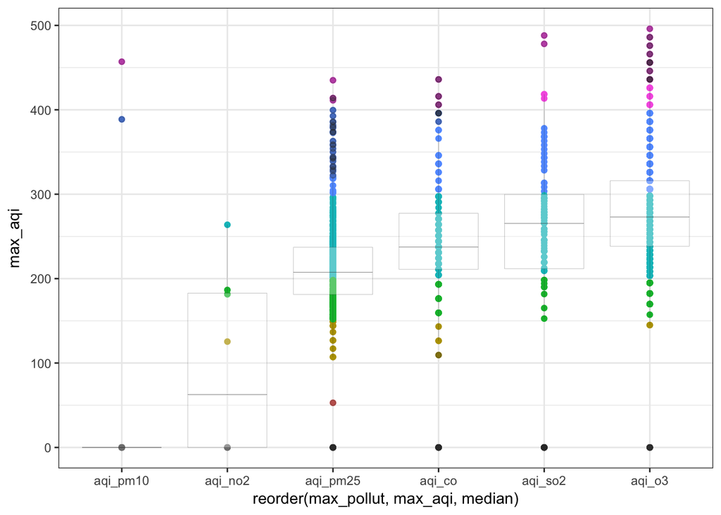

```r
#From above, o3's AQI score was used for final AQI score most of the time, followed by pm25

#Below we observe that the point estimate for the o3's AQI score is the highest.
aqi %>%
  ggplot(aes(reorder(max_pollut, max_aqi, median), max_aqi)) +
  geom_point(aes(col = final_cat)) +
  geom_boxplot(size = 0.05, alpha = 0.3)+
  theme_bw()+
  theme(legend.position = "none")
```

```r
aqi %>%
  group_by(final_cat) %>%
  summarise(freq = n()) %>%
  mutate(prop = freq / sum(freq))
```

```
## # A tibble: 7 x 3
##   final_cat  freq     prop
##   <fct>     <int>    <dbl>
## 1 good          1 0.000629
## 2 moderate     19 0.0119
## 3 bad         225 0.142
## 4 very bad    958 0.603
## 5 dangerous   297 0.187
## 6 toxic        45 0.0283
## 7 <NA>         45 0.0283
```

```r
summary(aqi$final_cat)
```

```
## very good      good  moderate       bad  very bad dangerous     toxic
##         0         1        19       225       958       297        45
##      NA's
##        45
```

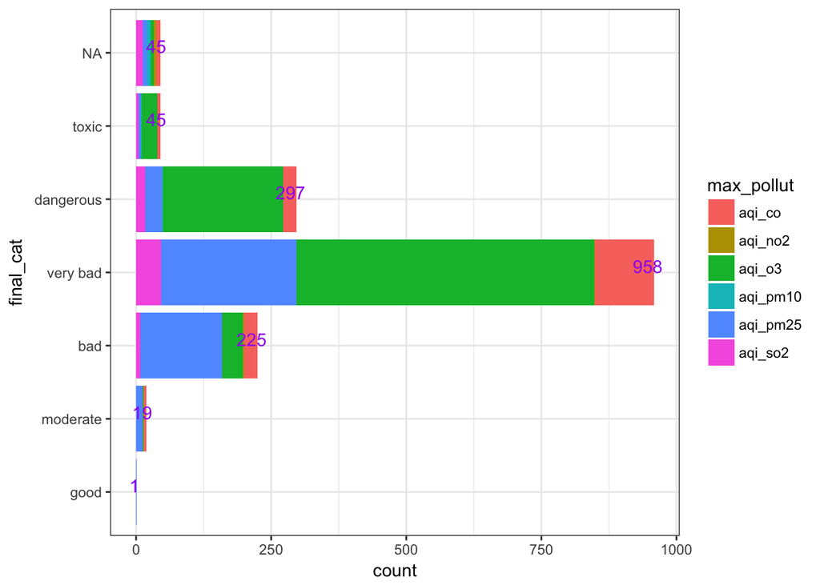

```r
#Notice that there is not a single observation that fall into the "very good" category


aqi %>%
  ggplot(aes(final_cat))+
  geom_bar(aes(fill = max_pollut))+
  geom_text(stat = 'count' , aes(label = ..count..), vjust=0, hjust=0.7, col = "purple") +
  coord_flip() +
  theme_bw()
```

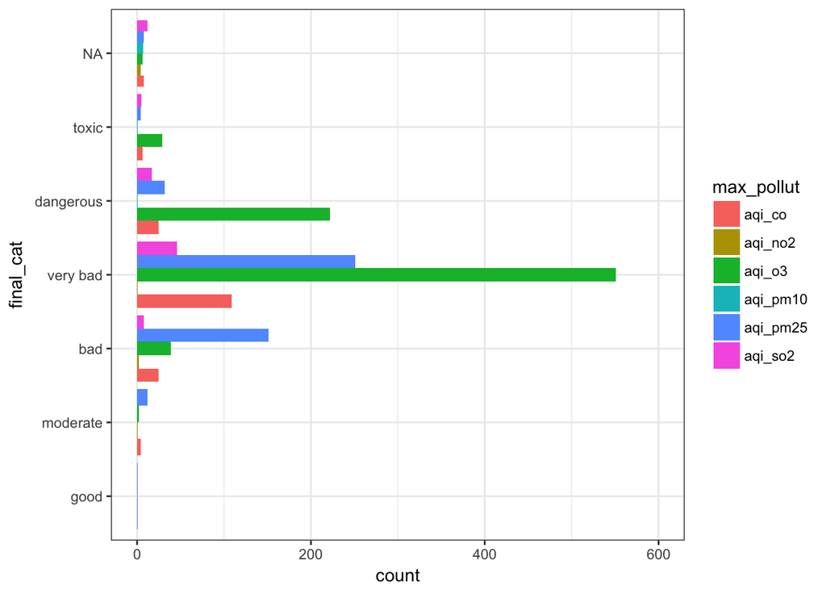

```r
aqi %>%
  ggplot(aes(final_cat))+
  geom_bar(aes(fill = max_pollut), , position = "dodge")+
  ylim(c(0, 600)) +
  # geom_text(stat = 'count' , aes(label = ..count..),
  #           vjust=0, hjust=0.7, col = "purple") +
  coord_flip() +
  theme_bw()
```

```r
#Notice the dominance of o3's AQI score as the category gets worse!
```

Overall, o3 seems to be the most problematic pollutant. This contradicts our initial few plots where we concluded that pm25 seemed to be most problematic one. BUT for the “bad” and “moderate” categories, pm25 does seem to be the major pollutant.

### Preparing for Statistical Analysis

If I want to do clustering or PCA, I will use the entire data set: aqi. If I want to do classification, I will need a training set and testing set. I decided to use 85% of my data for training, as you can see below. Also, from now on, I will always use lucky **three** for seed.

```r
set.seed(3)
#Training set: aqi_train
aqi_train <- aqi %>%
  sample_frac(0.85)    #85% <- I will use 85% of the data as the training set

#Testing set: aqi_test
aqi_test <- aqi %>%
  setdiff(aqi_train)

#Let's check thier dimensions
dim(aqi)       #1590   31
```

```
## [1] 1590   31
```

```r
dim(aqi_train) #1352   31
```

```
## [1] 1352   31
```

```r
dim(aqi_test)  #233    31
```

```
## [1] 233  31
```